```python
# Library to suppress warnings or deprecation notes
import warnings

warnings.filterwarnings("ignore")

# Libraries to help with reading and manipulating data
import numpy as np
import pandas as pd

# Libraries to help with data visualization
import matplotlib.pyplot as plt

%matplotlib inline
import seaborn as sns

# Library to split data
from sklearn.model_selection import train_test_split

# Libraries to import decision tree classifier and different ensemble classifiers
from sklearn.ensemble import BaggingClassifier
from sklearn.ensemble import RandomForestClassifier
from sklearn.tree import DecisionTreeClassifier
from sklearn import tree

# Libtune to tune model, get different metric scores
from sklearn import metrics
from sklearn.metrics import (
    confusion_matrix,
    classification_report,
    accuracy_score,
    precision_score,
    recall_score,
    f1_score,
    confusion_matrix,
    roc_auc_score,
    precision_recall_curve,
    roc_curve,
    make_scorer,
)
from sklearn.model_selection import GridSearchCV
```

```python
bank = pd.read_csv("UniversalBank.csv")
```

# Data Preparation

```python
ub = bank.copy()
```

```python
ub.head(10)
```

|  | ID | Age | Experience | Income | ZIP Code | Family | CCAvg | Education | Mortgage | Personal Loan | Securities Account | CD Account | Online | CreditCard |
| --- | --- | --- | --- | --- | --- | --- | --- | --- | --- | --- | --- | --- | --- | --- |
| 0 | 1 | 25 | 1 | 49 | 91107 | 4 | 1.6 | 1 | 0 | 0 | 1 | 0 | 0 | 0 |
| 1 | 2 | 45 | 19 | 34 | 90089 | 3 | 1.5 | 1 | 0 | 0 | 1 | 0 | 0 | 0 |
| 2 | 3 | 39 | 15 | 11 | 94720 | 1 | 1.0 | 1 | 0 | 0 | 0 | 0 | 0 | 0 |
| 3 | 4 | 35 | 9 | 100 | 94112 | 1 | 2.7 | 2 | 0 | 0 | 0 | 0 | 0 | 0 |
| 4 | 5 | 35 | 8 | 45 | 91330 | 4 | 1.0 | 2 | 0 | 0 | 0 | 0 | 0 | 1 |
| 5 | 6 | 37 | 13 | 29 | 92121 | 4 | 0.4 | 2 | 155 | 0 | 0 | 0 | 1 | 0 |
| 6 | 7 | 53 | 27 | 72 | 91711 | 2 | 1.5 | 2 | 0 | 0 | 0 | 0 | 1 | 0 |
| 7 | 8 | 50 | 24 | 22 | 93943 | 1 | 0.3 | 3 | 0 | 0 | 0 | 0 | 0 | 1 |
| 8 | 9 | 35 | 10 | 81 | 90089 | 3 | 0.6 | 2 | 104 | 0 | 0 | 0 | 1 | 0 |
| 9 | 10 | 34 | 9 | 180 | 93023 | 1 | 8.9 | 3 | 0 | 1 | 0 | 0 | 0 | 0 |

```python
ub.shape
```

```
(5000, 14)
```

```python
ub.info()
```

```
<class 'pandas.core.frame.DataFrame'>
RangeIndex: 5000 entries, 0 to 4999
Data columns (total 14 columns):
 #   Column              Non-Null Count  Dtype
---  ------              --------------  -----
 0   ID                  5000 non-null   int64
 1   Age                 5000 non-null   int64
 2   Experience          5000 non-null   int64
 3   Income              5000 non-null   int64
 4   ZIP Code            5000 non-null   int64
 5   Family              5000 non-null   int64
 6   CCAvg               5000 non-null   float64
 7   Education           5000 non-null   int64
 8   Mortgage            5000 non-null   int64
 9   Personal Loan       5000 non-null   int64
 10  Securities Account  5000 non-null   int64
 11  CD Account          5000 non-null   int64
 12  Online              5000 non-null   int64
 13  CreditCard          5000 non-null   int64
dtypes: float64(1), int64(13)
memory usage: 547.0 KB
```

```python
ub.rename(columns={'Personal Loan': 'PersonalLoan'}, inplace=True)
ub.rename(columns={'Securities Account': 'SecuritiesAccount'}, inplace=True)
ub.rename(columns={'CD Account': 'CDAccount'}, inplace=True)
```

```python
ub.Family = ub.Family.astype('category')
ub.Education = ub.Education.astype('category')
ub.Online = ub.Online.astype('category')
ub.CreditCard = ub.CreditCard.astype('category')
ub.PersonalLoan = ub.PersonalLoan.astype('category')
ub.SecuritiesAccount = ub.SecuritiesAccount.astype('category')
ub.CDAccount = ub.CDAccount.astype('category')
```

```python
# Select relevant variables
da = ub[['Age', 'Experience', 'Income', 'Family','CCAvg', 'Education', 'Mortgage', 'PersonalLoan', 'SecuritiesAccount','CDAccount', 'Online', 'CreditCard']]
```

```python
da.info()
```

```
<class 'pandas.core.frame.DataFrame'>
RangeIndex: 5000 entries, 0 to 4999
Data columns (total 12 columns):
 #   Column             Non-Null Count  Dtype
---  ------             --------------  -----
 0   Age                5000 non-null   int64
 1   Experience         5000 non-null   int64
 2   Income             5000 non-null   int64
 3   Family             5000 non-null   category
 4   CCAvg              5000 non-null   float64
 5   Education          5000 non-null   category
 6   Mortgage           5000 non-null   int64
 7   PersonalLoan       5000 non-null   category
 8   SecuritiesAccount  5000 non-null   category
 9   CDAccount          5000 non-null   category
 10  Online             5000 non-null   category
 11  CreditCard         5000 non-null   category
dtypes: category(7), float64(1), int64(4)
memory usage: 230.6 KB
```

```python
da.describe(include="all")
```

|  | Age | Experience | Income | Family | CCAvg | Education | Mortgage | PersonalLoan | SecuritiesAccount | CDAccount | Online | CreditCard |
| --- | --- | --- | --- | --- | --- | --- | --- | --- | --- | --- | --- | --- |
| count | 5000.000000 | 5000.000000 | 5000.000000 | 5000.0 | 5000.000000 | 5000.0 | 5000.000000 | 5000.0 | 5000.0 | 5000.0 | 5000.0 | 5000.0 |
| unique | NaN | NaN | NaN | 4.0 | NaN | 3.0 | NaN | 2.0 | 2.0 | 2.0 | 2.0 | 2.0 |
| top | NaN | NaN | NaN | 1.0 | NaN | 1.0 | NaN | 0.0 | 0.0 | 0.0 | 1.0 | 0.0 |
| freq | NaN | NaN | NaN | 1472.0 | NaN | 2096.0 | NaN | 4520.0 | 4478.0 | 4698.0 | 2984.0 | 3530.0 |
| mean | 45.338400 | 20.104600 | 73.774200 | NaN | 1.937938 | NaN | 56.498800 | NaN | NaN | NaN | NaN | NaN |
| std | 11.463166 | 11.467954 | 46.033729 | NaN | 1.747659 | NaN | 101.713802 | NaN | NaN | NaN | NaN | NaN |
| min | 23.000000 | -3.000000 | 8.000000 | NaN | 0.000000 | NaN | 0.000000 | NaN | NaN | NaN | NaN | NaN |
| 25% | 35.000000 | 10.000000 | 39.000000 | NaN | 0.700000 | NaN | 0.000000 | NaN | NaN | NaN | NaN | NaN |
| 50% | 45.000000 | 20.000000 | 64.000000 | NaN | 1.500000 | NaN | 0.000000 | NaN | NaN | NaN | NaN | NaN |
| 75% | 55.000000 | 30.000000 | 98.000000 | NaN | 2.500000 | NaN | 101.000000 | NaN | NaN | NaN | NaN | NaN |
| max | 67.000000 | 43.000000 | 224.000000 | NaN | 10.000000 | NaN | 635.000000 | NaN | NaN | NaN | NaN | NaN |

```python
#we knowe the Experience values must be possitive we will change any negative Experience value by the mean
da['Experience'][da['Experience'] < 0] = da['Experience'].mean()
da.describe()
```

|  | Age | Experience | Income | CCAvg | Mortgage |
| --- | --- | --- | --- | --- | --- |
| count | 5000.000000 | 5000.000000 | 5000.000000 | 5000.000000 | 5000.000000 |
| mean | 45.338400 | 20.328688 | 73.774200 | 1.937938 | 56.498800 |
| std | 11.463166 | 11.253009 | 46.033729 | 1.747659 | 101.713802 |
| min | 23.000000 | 0.000000 | 8.000000 | 0.000000 | 0.000000 |
| 25% | 35.000000 | 11.000000 | 39.000000 | 0.700000 | 0.000000 |
| 50% | 45.000000 | 20.104600 | 64.000000 | 1.500000 | 0.000000 |
| 75% | 55.000000 | 30.000000 | 98.000000 | 2.500000 | 101.000000 |
| max | 67.000000 | 43.000000 | 224.000000 | 10.000000 | 635.000000 |

```python
da.isnull().sum()
```

```
Age                  0
Experience           0
Income               0
Family               0
CCAvg                0
Education            0
Mortgage             0
PersonalLoan         0
SecuritiesAccount    0
CDAccount            0
Online               0
CreditCard           0
dtype: int64
```

```python
da.head(10)
```

|  | Age | Experience | Income | Family | CCAvg | Education | Mortgage | PersonalLoan | SecuritiesAccount | CDAccount | Online | CreditCard |
| --- | --- | --- | --- | --- | --- | --- | --- | --- | --- | --- | --- | --- |
| 0 | 25 | 1.0 | 49 | 4 | 1.6 | 1 | 0 | 0 | 1 | 0 | 0 | 0 |
| 1 | 45 | 19.0 | 34 | 3 | 1.5 | 1 | 0 | 0 | 1 | 0 | 0 | 0 |
| 2 | 39 | 15.0 | 11 | 1 | 1.0 | 1 | 0 | 0 | 0 | 0 | 0 | 0 |
| 3 | 35 | 9.0 | 100 | 1 | 2.7 | 2 | 0 | 0 | 0 | 0 | 0 | 0 |
| 4 | 35 | 8.0 | 45 | 4 | 1.0 | 2 | 0 | 0 | 0 | 0 | 0 | 1 |
| 5 | 37 | 13.0 | 29 | 4 | 0.4 | 2 | 155 | 0 | 0 | 0 | 1 | 0 |
| 6 | 53 | 27.0 | 72 | 2 | 1.5 | 2 | 0 | 0 | 0 | 0 | 1 | 0 |
| 7 | 50 | 24.0 | 22 | 1 | 0.3 | 3 | 0 | 0 | 0 | 0 | 0 | 1 |
| 8 | 35 | 10.0 | 81 | 3 | 0.6 | 2 | 104 | 0 | 0 | 0 | 1 | 0 |
| 9 | 34 | 9.0 | 180 | 1 | 8.9 | 3 | 0 | 1 | 0 | 0 | 0 | 0 |

# Data Explore (EDA)-Bivariate Analysis

```python
def boxplot(x):
    plt.figure(figsize=(10, 7))
    sns.boxplot(data=da, x="PersonalLoan", y=da[x], palette="PuBu")
    plt.show()
```

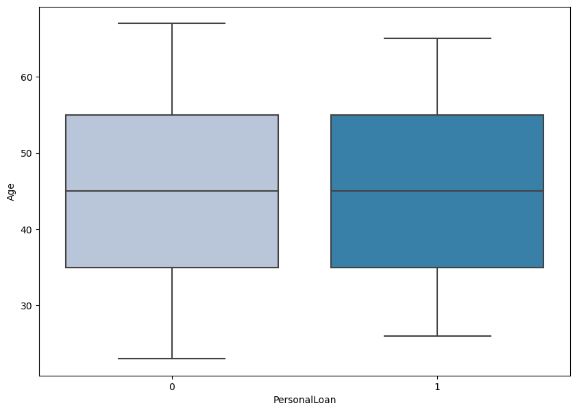

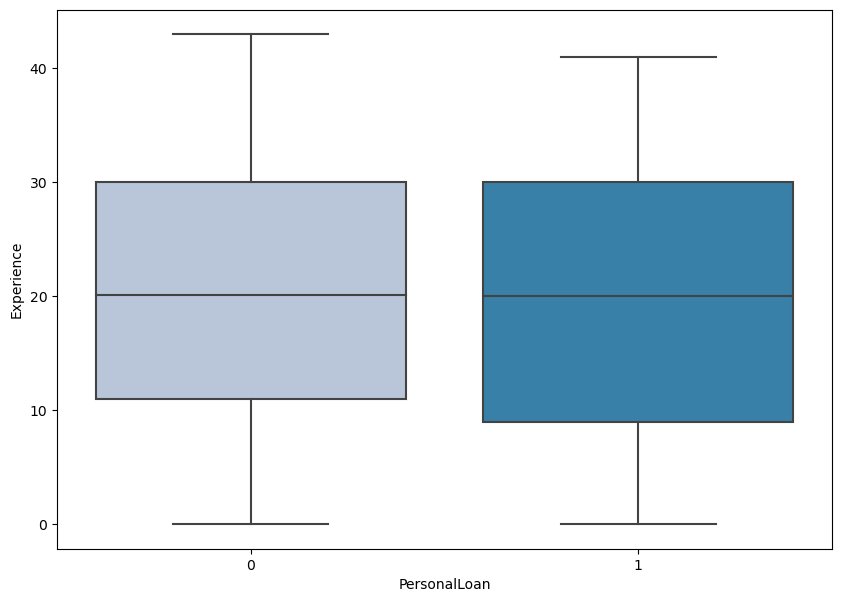

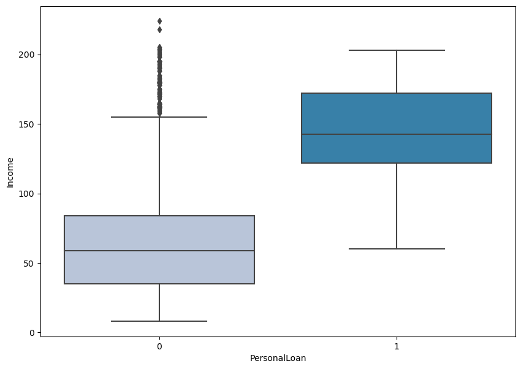

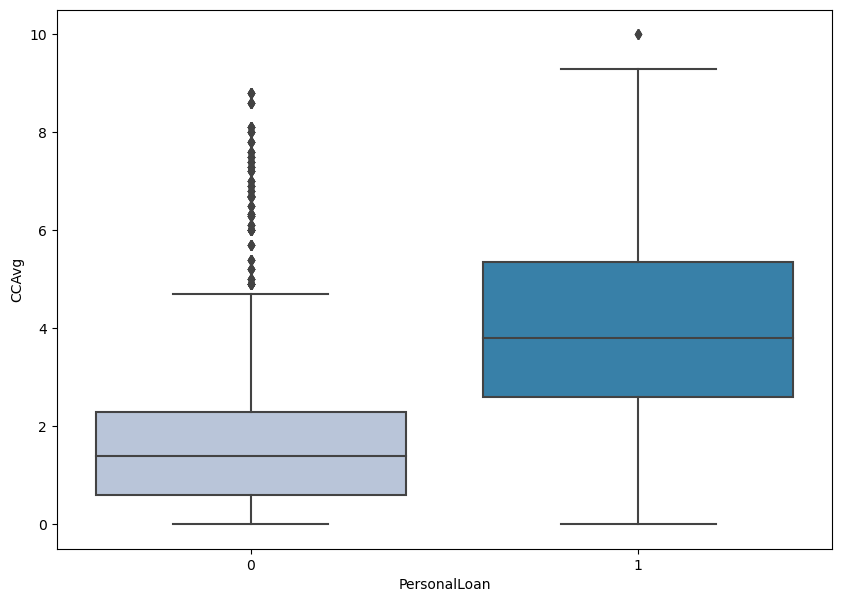

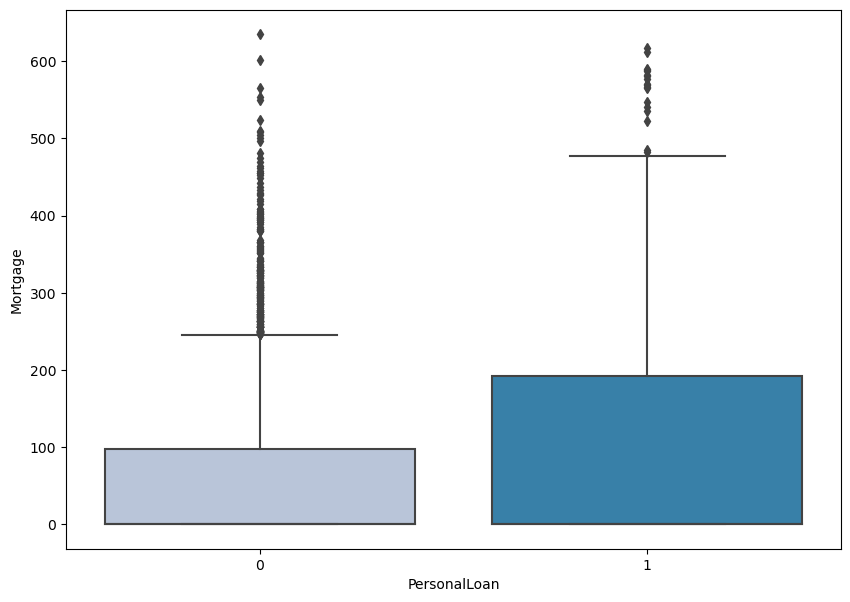

```python
boxplot("Age")
boxplot("Experience")
boxplot("Income")
boxplot("CCAvg")
boxplot("Mortgage")
```

### Key Observations

1.people who have High income are more likely to accept the Peronal Loan.

2.There is no difference between the Age and Experience of a person who take the loan or not.

3.people who have personal loan have higher Mortgage and CCavg.

```python
def stacked_barplot(data, predictor, target):
    """
    Print the category counts and plot a stacked bar chart

    data: dataframe
    predictor: independent variable
    target: target variable
    """
    count = data[predictor].nunique()
    sorter = data[target].value_counts().index[-1]
    tab1 = pd.crosstab(data[predictor], data[target], margins=True).sort_values(
        by=sorter, ascending=False
    )
    print(tab1)
    print("-" * 120)
    tab = pd.crosstab(data[predictor], data[target], normalize="index").sort_values(
        by=sorter, ascending=False
    )
    tab.plot(kind="bar", stacked=True, figsize=(count + 5, 6))
    plt.legend(
        loc="lower left",
        frameon=False,
    )
    plt.legend(loc="upper left", bbox_to_anchor=(1, 1))
    plt.show()
```

```
PersonalLoan     0    1   All
Family
All           4520  480  5000
4             1088  134  1222
3              877  133  1010
1             1365  107  1472
2             1190  106  1296
------------------------------------------------------------------------------------------------------------------------
```

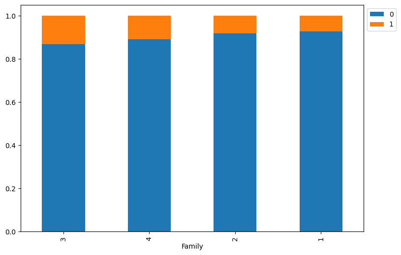

```
PersonalLoan     0    1   All
Education
All           4520  480  5000
3             1296  205  1501
2             1221  182  1403
1             2003   93  2096
------------------------------------------------------------------------------------------------------------------------
```

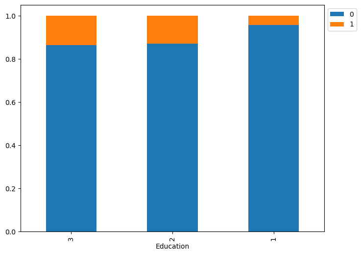

```
PersonalLoan          0    1   All
SecuritiesAccount
All                4520  480  5000
0                  4058  420  4478
1                   462   60   522
------------------------------------------------------------------------------------------------------------------------
```

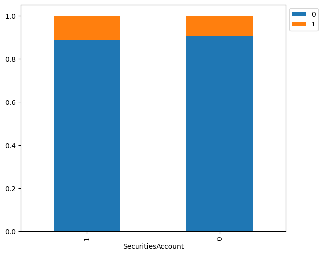

```
PersonalLoan     0    1   All
CDAccount
All           4520  480  5000
0             4358  340  4698
1              162  140   302
------------------------------------------------------------------------------------------------------------------------
```

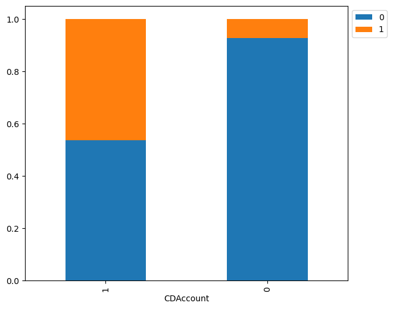

```
PersonalLoan     0    1   All
Online
All           4520  480  5000
1             2693  291  2984
0             1827  189  2016
------------------------------------------------------------------------------------------------------------------------
```

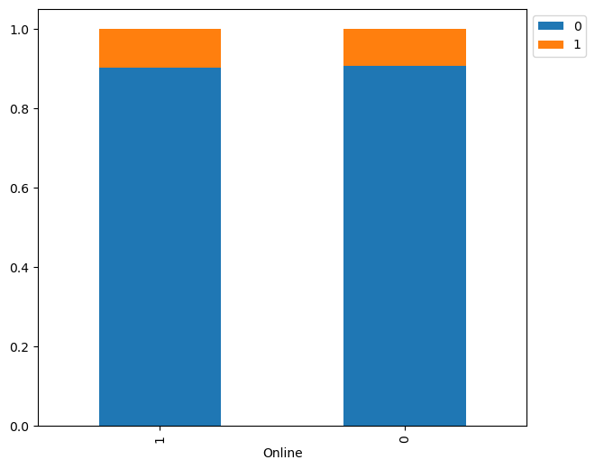

```
PersonalLoan     0    1   All
CreditCard
All           4520  480  5000
0             3193  337  3530
1             1327  143  1470
------------------------------------------------------------------------------------------------------------------------
```

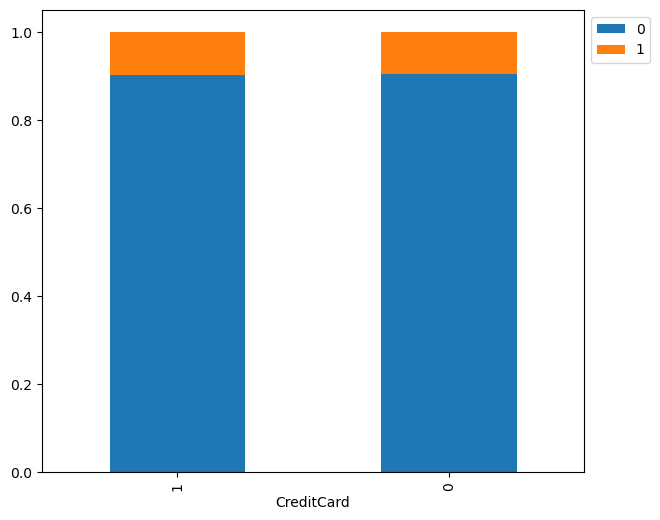

```python
stacked_barplot(da, "Family", "PersonalLoan")
stacked_barplot(da, "Education", "PersonalLoan")
stacked_barplot(da, "SecuritiesAccount", "PersonalLoan")
stacked_barplot(da, "CDAccount", "PersonalLoan")
stacked_barplot(da, "Online", "PersonalLoan")
stacked_barplot(da, "CreditCard", "PersonalLoan")
```

### Key Observations -

1. CDAccount appear to be strong indicators of PersoanlLoan.
2. People who have large family and higher education could be good indicators of Personal Loan.
3. Other factors appear to be not very good indicators of PersoanlLoan.

# Model Building

```python
da = pd.get_dummies(da, columns=['Family','Education','SecuritiesAccount','CDAccount','Online', 'CreditCard'], drop_first=True)
```

```python
da.head(10)
```

|  | Age | Experience | Income | CCAvg | Mortgage | PersonalLoan | Family_2 | Family_3 | Family_4 | Education_2 | Education_3 | SecuritiesAccount_1 | CDAccount_1 | Online_1 | CreditCard_1 |
| --- | --- | --- | --- | --- | --- | --- | --- | --- | --- | --- | --- | --- | --- | --- | --- |
| 0 | 25 | 1.0 | 49 | 1.6 | 0 | 0 | 0 | 0 | 1 | 0 | 0 | 1 | 0 | 0 | 0 |
| 1 | 45 | 19.0 | 34 | 1.5 | 0 | 0 | 0 | 1 | 0 | 0 | 0 | 1 | 0 | 0 | 0 |
| 2 | 39 | 15.0 | 11 | 1.0 | 0 | 0 | 0 | 0 | 0 | 0 | 0 | 0 | 0 | 0 | 0 |
| 3 | 35 | 9.0 | 100 | 2.7 | 0 | 0 | 0 | 0 | 0 | 1 | 0 | 0 | 0 | 0 | 0 |
| 4 | 35 | 8.0 | 45 | 1.0 | 0 | 0 | 0 | 0 | 1 | 1 | 0 | 0 | 0 | 0 | 1 |
| 5 | 37 | 13.0 | 29 | 0.4 | 155 | 0 | 0 | 0 | 1 | 1 | 0 | 0 | 0 | 1 | 0 |
| 6 | 53 | 27.0 | 72 | 1.5 | 0 | 0 | 1 | 0 | 0 | 1 | 0 | 0 | 0 | 1 | 0 |
| 7 | 50 | 24.0 | 22 | 0.3 | 0 | 0 | 0 | 0 | 0 | 0 | 1 | 0 | 0 | 0 | 1 |
| 8 | 35 | 10.0 | 81 | 0.6 | 104 | 0 | 0 | 1 | 0 | 1 | 0 | 0 | 0 | 1 | 0 |
| 9 | 34 | 9.0 | 180 | 8.9 | 0 | 1 | 0 | 0 | 0 | 0 | 1 | 0 | 0 | 0 | 0 |

```python
from sklearn.model_selection import train_test_split

X = da.drop('PersonalLoan', axis=1)
y = da['PersonalLoan']

X_train, X_test, y_train, y_test = train_test_split(X, y, test_size=0.3, random_state=1)
```

```python
X_train.head()
```

|  | Age | Experience | Income | CCAvg | Mortgage | Family_2 | Family_3 | Family_4 | Education_2 | Education_3 | SecuritiesAccount_1 | CDAccount_1 | Online_1 | CreditCard_1 |
| --- | --- | --- | --- | --- | --- | --- | --- | --- | --- | --- | --- | --- | --- | --- |
| 1334 | 47 | 22.0 | 35 | 1.3 | 0 | 1 | 0 | 0 | 0 | 0 | 0 | 0 | 1 | 0 |
| 4768 | 38 | 14.0 | 39 | 2.0 | 0 | 0 | 0 | 0 | 1 | 0 | 0 | 0 | 1 | 0 |
| 65 | 59 | 35.0 | 131 | 3.8 | 0 | 0 | 0 | 0 | 0 | 0 | 0 | 0 | 1 | 1 |
| 177 | 29 | 3.0 | 65 | 1.8 | 244 | 0 | 0 | 1 | 1 | 0 | 0 | 0 | 0 | 0 |
| 4489 | 39 | 13.0 | 21 | 0.2 | 0 | 0 | 1 | 0 | 1 | 0 | 0 | 0 | 1 | 0 |

```python
X_train.info()
```

```
<class 'pandas.core.frame.DataFrame'>
Int64Index: 3500 entries, 1334 to 235
Data columns (total 14 columns):
 #   Column               Non-Null Count  Dtype
---  ------               --------------  -----
 0   Age                  3500 non-null   int64
 1   Experience           3500 non-null   float64
 2   Income               3500 non-null   int64
 3   CCAvg                3500 non-null   float64
 4   Mortgage             3500 non-null   int64
 5   Family_2             3500 non-null   uint8
 6   Family_3             3500 non-null   uint8
 7   Family_4             3500 non-null   uint8
 8   Education_2          3500 non-null   uint8
 9   Education_3          3500 non-null   uint8
 10  SecuritiesAccount_1  3500 non-null   uint8
 11  CDAccount_1          3500 non-null   uint8
 12  Online_1             3500 non-null   uint8
 13  CreditCard_1         3500 non-null   uint8
dtypes: float64(2), int64(3), uint8(9)
memory usage: 194.8 KB
```

```python
# defining a function to compute different metrics to check performance of a classification model built using statsmodels
def model_performance_classification(model, predictors, target, threshold=0.5):
    """
    Function to compute different metrics to check classification model performance

    model: classifier
    predictors: independent variables
    target: dependent variable
    threshold: threshold for classifying the observation as class 1
    """

    # checking which probabilities are greater than threshold
    pred_temp = model.predict(predictors) > threshold
    # rounding off the above values to get classes
    pred = np.round(pred_temp)

    acc = accuracy_score(target, pred)  # to compute Accuracy
    recall = recall_score(target, pred)  # to compute Recall
    precision = precision_score(target, pred)  # to compute Precision
    f1 = f1_score(target, pred)  # to compute F1-score

    # creating a dataframe of metrics
    df_perf = pd.DataFrame(
        {
            "Accuracy": acc,
            "Recall": recall,
            "Precision": precision,
            "F1": f1,
        },
        index=[0],
    )

    return df_perf
```

```python
# Importing library
import statsmodels.api as sm
from statsmodels.tools.tools import add_constant
```

```python
# fitting logistic regression model
logit = sm.Logit(y_train, X_train.astype(float))
lg = logit.fit(disp=False)

print(lg.summary())
```

```
                           Logit Regression Results
==============================================================================
Dep. Variable:           PersonalLoan   No. Observations:                 3500
Model:                          Logit   Df Residuals:                     3486
Method:                           MLE   Df Model:                           13
Date:                Mon, 17 Apr 2023   Pseudo R-squ.:                  0.5203
Time:                        03:21:35   Log-Likelihood:                -525.44
converged:                       True   LL-Null:                       -1095.5
Covariance Type:            nonrobust   LLR p-value:                1.405e-235
=======================================================================================
                          coef    std err          z      P>|z|      [0.025      0.975]
---------------------------------------------------------------------------------------
Age                    -0.2831      0.014    -20.136      0.000      -0.311      -0.256
Experience              0.2493      0.017     14.750      0.000       0.216       0.282
Income                  0.0405      0.002     16.243      0.000       0.036       0.045
CCAvg                   0.1565      0.047      3.314      0.001       0.064       0.249
Mortgage                0.0005      0.001      0.777      0.437      -0.001       0.002
Family_2               -1.0091      0.231     -4.374      0.000      -1.461      -0.557
Family_3                0.9389      0.227      4.129      0.000       0.493       1.385
Family_4                0.3795      0.237      1.605      0.109      -0.084       0.843
Education_2             2.0943      0.227      9.225      0.000       1.649       2.539
Education_3             2.3030      0.227     10.135      0.000       1.858       2.748
SecuritiesAccount_1    -1.6062      0.348     -4.622      0.000      -2.287      -0.925
CDAccount_1             4.2165      0.371     11.373      0.000       3.490       4.943
Online_1               -1.0594      0.175     -6.041      0.000      -1.403      -0.716
CreditCard_1           -1.5436      0.248     -6.215      0.000      -2.030      -1.057
=======================================================================================
```

```python
print("Training performance:")
model_performance_classification(lg, X_train, y_train)
```

```
Training performance:
```

|  | Accuracy | Recall | Precision | F1 |
| --- | --- | --- | --- | --- |
| 0 | 0.945143 | 0.610272 | 0.762264 | 0.677852 |

```python
print("Testing performance:")
model_performance_classification(lg, X_test, y_test)
```

```
Testing performance:
```

|  | Accuracy | Recall | Precision | F1 |
| --- | --- | --- | --- | --- |
| 0 | 0.94 | 0.536913 | 0.792079 | 0.64 |

```python
lg_model_test_perf=model_performance_classification(lg, X_test, y_test)
```

```python
# defining a function to plot the confusion_matrix of a classification model


def confusion_matrix_statsmodels(model, predictors, target, threshold=0.5):
    """
    To plot the confusion_matrix with percentages

    model: classifier
    predictors: independent variables
    target: dependent variable
    threshold: threshold for classifying the observation as class 1
    """
    y_pred = model.predict(predictors) > threshold
    cm = confusion_matrix(target, y_pred)
    group_names = ["True Neg", "False Pos", "False Neg", "True Pos"]
    group_counts = ["{0:0.0f}".format(value) for value in cm.flatten()]
    group_percentages = ["{0:.2%}".format(value) for value in cm.flatten() / np.sum(cm)]
    labels = [
        f"{v1}\n{v2}\n{v3}"
        for v1, v2, v3 in zip(group_names, group_counts, group_percentages)
    ]
    labels = np.asarray(labels).reshape(2, 2)
    sns.heatmap(cm, annot=labels, fmt="", cmap="Blues")
```

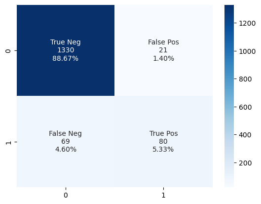

```python
confusion_matrix_statsmodels(lg, X_test, y_test, threshold=0.5)
```

### Decision Tree model

```python
# Fitting the model
dTree = DecisionTreeClassifier(random_state=1,criterion="gini", max_depth=10)
dTree.fit(X_train, y_train)
```

```
DecisionTreeClassifier(max_depth=10, random_state=1)
```

```python
# Calculating different metrics
dTree_model_train_perf = model_performance_classification(dTree, X_train, y_train)
print("Training performance:\n", dTree_model_train_perf)
dTree_model_test_perf = model_performance_classification(dTree, X_test, y_test)
print("Testing performance:\n", dTree_model_test_perf)
```

```
Training performance:
    Accuracy  Recall  Precision   F1
0       1.0     1.0        1.0  1.0
Testing performance:
    Accuracy    Recall  Precision        F1
0     0.982  0.899329   0.917808  0.908475
```

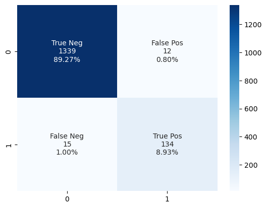

```python
# Creating confusion matrix
confusion_matrix_statsmodels(dTree, X_test, y_test)
```

# Tuning the LR model and Decision tree model

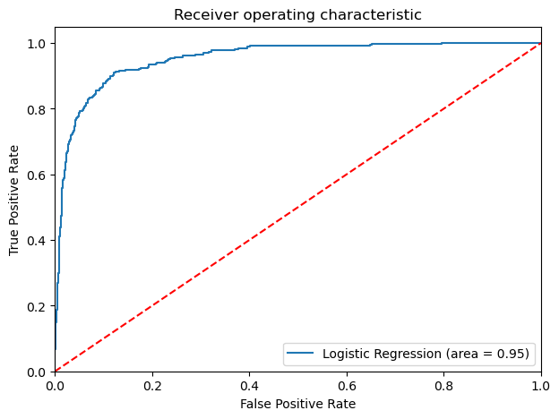

```python
logit_roc_auc_train = roc_auc_score(y_train, lg.predict(X_train))
fpr, tpr, thresholds = roc_curve(y_train, lg.predict(X_train))
plt.figure(figsize=(7, 5))
plt.plot(fpr, tpr, label="Logistic Regression (area = %0.2f)" % logit_roc_auc_train)
plt.plot([0, 1], [0, 1], "r--")
plt.xlim([0.0, 1.0])
plt.ylim([0.0, 1.05])
plt.xlabel("False Positive Rate")
plt.ylabel("True Positive Rate")
plt.title("Receiver operating characteristic")
plt.legend(loc="lower right")
plt.show()
```

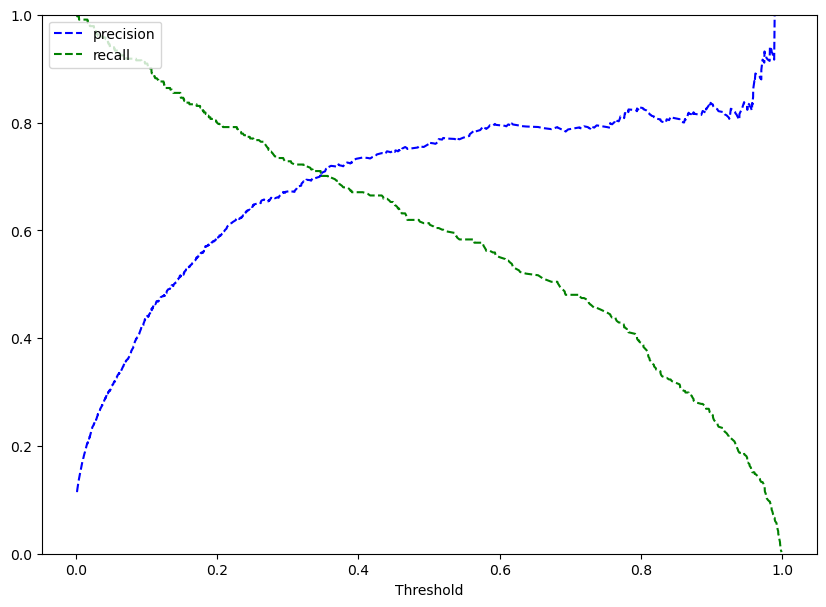

```python
y_scores = lg.predict(X_train)
prec, rec, tre = precision_recall_curve(
    y_train,
    y_scores,
)


def plot_prec_recall_vs_threshold(precisions, recalls, thresholds):
    plt.plot(thresholds, precisions[:-1], "b--", label="precision")
    plt.plot(thresholds, recalls[:-1], "g--", label="recall")
    plt.xlabel("Threshold")
    plt.legend(loc="upper left")
    plt.ylim([0, 1])


plt.figure(figsize=(10, 7))
plot_prec_recall_vs_threshold(prec, rec, tre)
plt.show()
```

### It appears that Precision and recall may be balanced at a thrshold around 0.32

```python
print("Training performance:")
model_performance_classification(lg, X_train, y_train, threshold=0.32)
```

```
Training performance:
```

|  | Accuracy | Recall | Precision | F1 |
| --- | --- | --- | --- | --- |
| 0 | 0.942857 | 0.722054 | 0.688761 | 0.705015 |

```python
print("Testing performance:")
model_performance_classification(lg, X_test, y_test, threshold=0.32)
```

```
Testing performance:
```

|  | Accuracy | Recall | Precision | F1 |
| --- | --- | --- | --- | --- |
| 0 | 0.939333 | 0.644295 | 0.716418 | 0.678445 |

```python
lg_tuned_model_test_perf=model_performance_classification(lg, X_test, y_test, threshold=0.32)
```

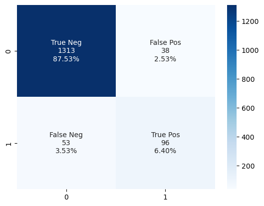

```python
confusion_matrix_statsmodels(lg, X_test, y_test, threshold=0.32)
```

### Tuning the Tree

```python
dTree_tuned = DecisionTreeClassifier(random_state=1
)  # using reverse class weights

# Grid of parameters to choose from
parameters = {
    "max_depth": np.arange(2, 10, 1),
    "max_leaf_nodes": [10,20,30,40],
    "min_impurity_decrease": [0.0001, 0.001, 0.01, 0.1],
}

# Type of scoring used to compare parameter combinations
scorer = metrics.make_scorer(
    metrics.recall_score
)  # Note that Recall is chosen here as the scorer.

# Run the grid search
grid_obj = GridSearchCV(dTree_tuned, parameters, scoring=scorer, cv=5)
grid_obj = grid_obj.fit(X_train, y_train)

# Set the clf to the best combination of parameters (which achieves the best score)
dTree_tuned = grid_obj.best_estimator_

# Fit the best algorithm to the data.
dTree_tuned.fit(X_train, y_train)
```

```
DecisionTreeClassifier(max_depth=8, max_leaf_nodes=40,
                       min_impurity_decrease=0.0001, random_state=1)
```

```
Training performance:
    Accuracy    Recall  Precision        F1
0  0.997714  0.975831        1.0  0.987768
Testing performance:
    Accuracy    Recall  Precision        F1
0  0.983333  0.892617    0.93662  0.914089
```

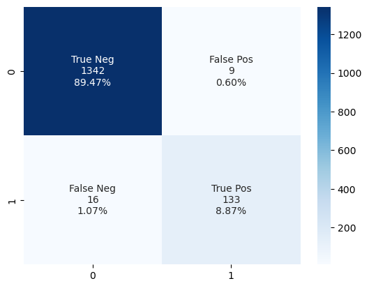

```python
# Calculating different metrics
dTree_tuned_model_train_perf = model_performance_classification(
    dTree_tuned, X_train, y_train
)
print("Training performance:\n", dTree_tuned_model_train_perf)
dTree_tuned_model_test_perf = model_performance_classification(
    dTree_tuned, X_test, y_test
)
print("Testing performance:\n", dTree_tuned_model_test_perf)
# Creating confusion matrix for test data
confusion_matrix_statsmodels(dTree_tuned, X_test, y_test)
```

#### The F1 score has increased slightly after hyperparameter tuning.

# Comparing all the models

```python
# testing performance comparison

models_test_comp_df = pd.concat(
    [
        dTree_model_test_perf.T,
        dTree_tuned_model_test_perf.T,
        lg_model_test_perf.T,
        lg_tuned_model_test_perf.T,
    ],
    axis=1,
)
models_test_comp_df.columns = [
    "Decision Tree",
    "Decision Tree Tuned",
    "Logistic regression",
    "Logistic regression Tuned",
]
print("Testing performance comparison:")
models_test_comp_df
```

```
Testing performance comparison:
```

|  | Decision Tree | Decision Tree Tuned | Logistic regression | Logistic regression Tuned |
| --- | --- | --- | --- | --- |
| Accuracy | 0.982000 | 0.983333 | 0.940000 | 0.939333 |
| Recall | 0.899329 | 0.892617 | 0.536913 | 0.644295 |
| Precision | 0.917808 | 0.936620 | 0.792079 | 0.716418 |
| F1 | 0.908475 | 0.914089 | 0.640000 | 0.678445 |

### The Decision Tree Tuned is the best model for our data as it has the highest F1 Score and giving a generalized performance as compared to other models.